# R Workshop 1 - Welcome to R!

Andrew Moles

Learning Developer, Digital Skills Lab

14 August, 2020

# What will this workshop cover?

The goal of this session is to get to started using RStudio, learn how to use variables and solve basic calculations in R. We will cover:

- Introduction to RStudio
- Using r as a calculator
- Assigning variables
- Numerical variables

# Information on how the session is run

We will be working in pairs:

- One shares the screen and the other requests remote control.
- Take turns on who types for each exercise.
- At the end save the script/markdown document and share it with your teammate in the chat.

What to do when getting stuck:

1. Ask your team members
2. Search online:
- The answer box on the top of Google’s results page
- stackoverflow.com (for task-specific solutions)
- https://www.r-bloggers.com/ (topic based tutorials)
3. Don’t struggle too long looking online, ask the trainer if you can’t find a solution!

Handing in answers:- Submit to teams assignment page

# Why R

R is a popular language, especially in data science, this can be seen in the TIOBE Index for August 2020.

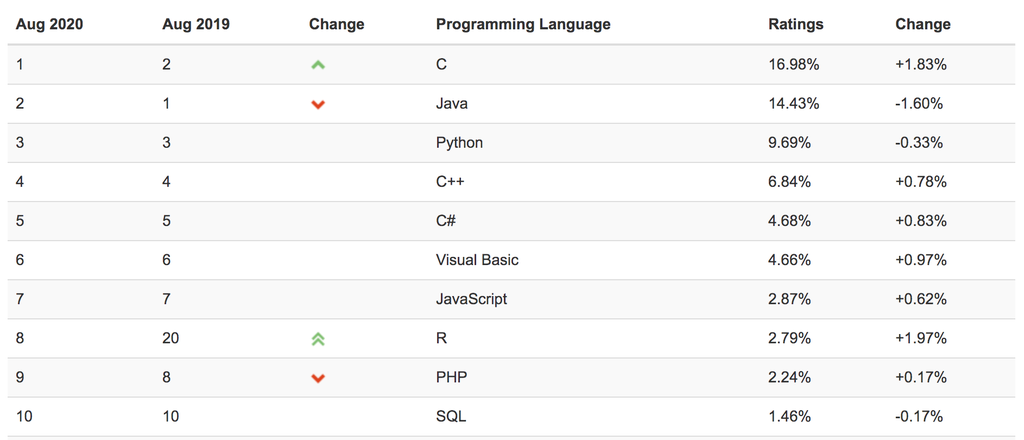

It has lots of strengths:

- Excellent at handling data
- Very good for statistics
- Open source
- You can do almost anything in R due to community written ‘packages’
- Makes pretty and complex data visualisations (see below)

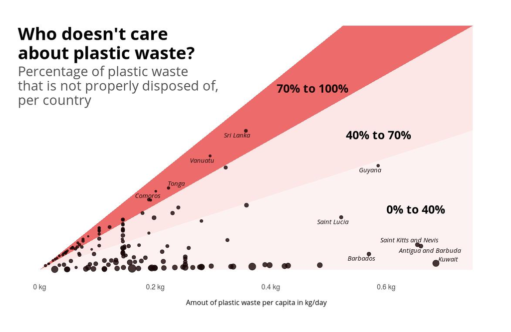

# Introduction to RStudio

RStudio by default has four main quadrants as shown below. The layout is customisable, as is the background.

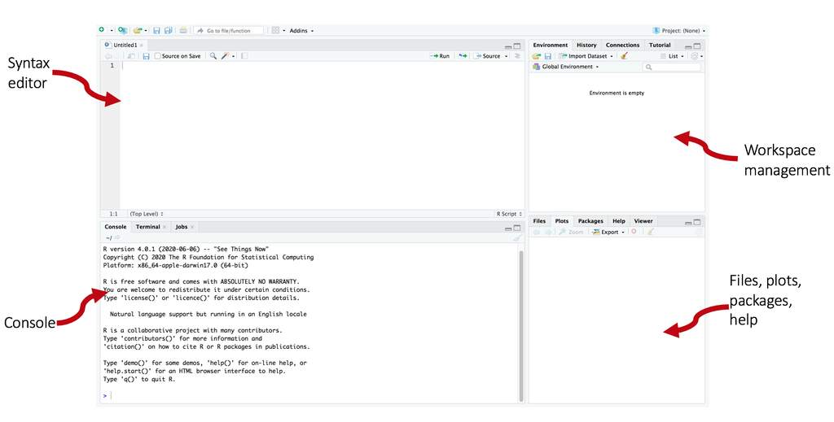

When you load RStudio the syntax editor will not be open. Try and open one just like as shown below.

[figure not shown]

# Using R markdown

For these workshops we will be using R Markdown. It allows you to have text (with simple formatting) and chunks of R code.

[figure not shown]

To run code in a code chunk either press the green play button or press Ctrl + Enter (or Cmd + Enter on Mac).

# Starting the session

Open the workshop1.rmd file I have sent and save it.

As we will be doing paired programming, each of you should have the file open and take turns to share the screen for each task/exercise. Whoever is screen sharing should copy and paste the code into the chat so that other has it to add to their own document.

# Using R as a calculator

We can use R to do simple or advanced calculations for us. Remember to run the code press the green play button or press Ctrl + Enter (or Cmd + Enter on Mac).

```r
7 * 6
```

```
## [1] 42
```

```r
5 / (2^2)
```

```
## [1] 1.25
```

```r
(16 - 4) + (1 * 9)
```

```
## [1] 21
```

## Exercise (R as calculator)

Use R to work out the following arithmetic:

1. $44 * 26$
2. $9.6/1.6$
3. $(12+4)^2$
4. $(4*9)/(5+6)$
5. $(22/36) * 100$

```r
# type your code here
```

# Assigning variables

A variable is a named storage of information. In our case today we are storing numbers.

We can assign variables by using <-. You should see the variable appear to your right in the global enviroment once you’ve run this command.

```r
height <- 155
```

We can then print the output of the variable by typing in its name.

```r
height
```

```
## [1] 155
```

## Task

When calling a variable, be careful to type it exactly (you can also copy it or use code completion to help).

Try calling the height variable, but spell it incorrectly. You should get an error with something like *Error: object ‘hieght’ not found*

```r
# type incorrect height call here
```

## Example

We can do calculations on these variables, just as we did before. We first assign the variables, then use them in the calculation.

```r
# test scores
Score1 <- 42
Score2 <- 92
Score3 <- 68
# average score calculation
AveScore <- (Score1+Score2+Score3)/3
# print average score
AveScore
```

```
## [1] 67.33333
```

You will have noticed the hashtags (#) with text in the above example. These are called comments. In later R sessions we will use a lot of comments to tell us (and others) what each line or section of code is doing.

```r
# this is a comment
```

## Reassigning variables

You can also change the value of a variable you have already assigned. Here we are going to add our new pay check to our previous bank balance. Be sure to run the code.

```r
# create variables
BankBalance <- 100
PayCheck <- 250
# add old bank balance and pay check, assigning result to bank balance
BankBalance <- BankBalance + PayCheck
# print bank balance
BankBalance
```

```
## [1] 350
```

## Task

Try and add another pay check of £50 to the bank balance variable.

1. Make a variable called PayCheck2 with a value of 50
2. Assign BankBalance, and calculate BankBalance + PayCheck2
3. Print the outcome

```r
# Reassigning variables task
```

## Exercise 1 (Assigning variables)

Use R to work out a body mass index (BMI) of someone who is 79kg, and 1.77m tall.

1. Assign the variables of weight and height
2. Assign the variable of BMI, and calculate the BMI based of the weight and height variables
3. Print the outcome
4. Add comments on what each line of code is doing

```r
# Exercise: BMI calculation
```

## Exercise 2 (Assigning variables)

Debug the code below that is finding the weighted average of a students coursework and exam scores. You should find three errors:

- logic (maths) error
- syntax error
- naming error

```r
# Exercise: weighted average debugging
exam1 <- 52
coursework1 <- 82
exam2 <- 78
coursework2 < 48

cw_weight <- 0.4
ex_weight <- 0.6

course1 <- (exam1 * ex_weight) + (coursework * cw_weight)
course2 <- (exam2 * ex_weight) + (coursework2 * cw_weight)

overall_grade <- (course1 + course2)/3

overall_grade
```

# Workshop survey

# Individual (take home) coding challenge

A take home coding task for you, which if you submit to Teams we will mark and give you feedback.

Task: Splitting a Pizza Pilgrims restaurant bill between 3 friends; Roger, Amal and Genevieve.

- Roger has a Calzone Ripieno (£11), and a San Pellegrino (£2).
- Amal has a Bufala (£9), and Birra Moretti (£4.50).
- Genevieve has a Portobello Mushroom & Truffle (£10), and water to drink.
- Genevieve and Amal also share a Nutella Pizza ring for dessert (£5.5).

[figure not shown]

1. Make a variable for each friend that is the sum of their order (e.g. Roger would be 11 + 2)
2. Make a variable for the shared food
3. Make a variable called TotalBill, and calculate their total bill
4. For those that shared food, add the shared food to their bill
5. Comment your code
6. Print the total bill and what each friend owes

```r
# individual coding challenge
```

# Submitting work to teams

# Recommended links

Recommended for more information on the RStudio environment: https://rladiessydney.org/courses/ryouwithme/01-basicbasics-1/  
Recommended for more information on using R Markdown: https://rmarkdown.rstudio.com/lesson-1.html